# MVA_Assignment8_Wine

2024-04-15

```r
# Load required libraries
library(cluster)     # For cluster analysis
library(readr)       # For reading data files
library(factoextra)  # For visualizing multivariate analysis results
library(magrittr)    # For using the pipe operator %>%
library(NbClust)     # For determining the optimal number of clusters
```

```r
#for loading csv data
library(readr)

# Read the CSV file
df <- read_csv("C:/Rutgers/Subjects/Spring Sem/Multivariate Analysis/Data/wine_new.csv")
#dataframe
df
```

```
## # A tibble: 1,143 × 12
##    `fixed acidity` `volatile acidity` `citric acid` `residual sugar` chlorides
##              <dbl>              <dbl>         <dbl>            <dbl>     <dbl>
##  1             7.4               0.7           0                 1.9     0.076
##  2             7.8               0.88          0                 2.6     0.098
##  3             7.8               0.76          0.04              2.3     0.092
##  4            11.2               0.28          0.56              1.9     0.075
##  5             7.4               0.7           0                 1.9     0.076
##  6             7.4               0.66          0                 1.8     0.075
##  7             7.9               0.6           0.06              1.6     0.069
##  8             7.3               0.65          0                 1.2     0.065
##  9             7.8               0.58          0.02              2       0.073
## 10             6.7               0.58          0.08              1.8     0.097
## # ℹ 1,133 more rows
## # ℹ 7 more variables: `free sulfur dioxide` <dbl>,
## #   `total sulfur dioxide` <dbl>, density <dbl>, pH <dbl>, sulphates <dbl>,
## #   alcohol <dbl>, quality <chr>
```

selected these columns because of positive and negative correlation, other columns were not beneficial for analysis

```r
# Assuming df is your dataframe
attach(df)

#selected these columns because of positive and negative correlation, other columns were not beneficial for analysis
selected_cols <- df[, c("volatile acidity", "citric acid", "chlorides", "sulphates", "alcohol","quality")]

selected_cols
```

```
## # A tibble: 1,143 × 6
##    `volatile acidity` `citric acid` chlorides sulphates alcohol quality
##                 <dbl>         <dbl>     <dbl>     <dbl>   <dbl> <chr>
##  1               0.7           0        0.076      0.56     9.4 Average
##  2               0.88          0        0.098      0.68     9.8 Average
##  3               0.76          0.04     0.092      0.65     9.8 Average
##  4               0.28          0.56     0.075      0.58     9.8 Good
##  5               0.7           0        0.076      0.56     9.4 Average
##  6               0.66          0        0.075      0.56     9.4 Average
##  7               0.6           0.06     0.069      0.46     9.4 Average
##  8               0.65          0        0.065      0.47    10   Very Good
##  9               0.58          0.02     0.073      0.57     9.5 Very Good
## 10               0.58          0.08     0.097      0.54     9.2 Average
## # ℹ 1,133 more rows
```

column 6 which is quality (Categorical: Target variable) Range parameters: Bad, Poor, Average, Good, Very Good, Excellent

Why I chose these attributes for cluster?

Answer:

volatile acidity: neagtively correlated to target variable

Citric acid: Positively correlated

similar correlation for columns selected showing no randomness

Group by quality and calculate the average of all other attributes within each group

Also assigning groups(random) Assigning groups to target variable:

Ideal range of quality is mention below (ascending)

group number is random

Bad: 2 Poor: 5 Average: 1 Good: 4 Very Good: 6 Excellent: 3

```r
# Group by column 6 and calculate the average of all other columns within each group
grouped_avg <- aggregate(. ~ quality, data = selected_cols[, -4], FUN = mean)

# Print the grouped averages
print(grouped_avg)
```

```
##     quality volatile acidity citric acid  chlorides   alcohol
## 1   Average        0.5852795   0.2401242 0.09177019  9.902277
## 2       Bad        0.8975000   0.2116667 0.10533333  9.691667
## 3 Excellent        0.4100000   0.4325000 0.07018750 11.937500
## 4      Good        0.5049567   0.2636797 0.08528139 10.655339
## 5      Poor        0.7000000   0.1657576 0.09478788 10.260606
## 6 Very Good        0.3936713   0.3865734 0.07521678 11.482634
```

setting target variable as row name by removing it first

grouping values based on alcohol and assigning a value to target variable based on that

Observation:

as alcohol content increase quality of alcohol also improves as highest scores are assigned to excellent quality of wine based on group number

Lowest values of alcohol are assigned to bad quality wine

```r
# Set the first column as row names
row.names(grouped_avg) <- grouped_avg[, 1]  # Assuming the first column contains row names

# Remove the first column from the dataframe
grouped_avg <- grouped_avg[, -1]

# View the dataframe
grouped_avg
```

```
##           volatile acidity citric acid  chlorides   alcohol
## Average          0.5852795   0.2401242 0.09177019  9.902277
## Bad              0.8975000   0.2116667 0.10533333  9.691667
## Excellent        0.4100000   0.4325000 0.07018750 11.937500
## Good             0.5049567   0.2636797 0.08528139 10.655339
## Poor             0.7000000   0.1657576 0.09478788 10.260606
## Very Good        0.3936713   0.3865734 0.07521678 11.482634
```

Observation:

as alcohol content increase quality of alcohol also improves as highest scores are assigned to excellent quality of wine based on group number

Lowest values of alcohol are assigned to bad quality wine

based on this we can observe correlation of attribute with respect to target variable as i mentioned above

positive value of attributes means correlated

Negative value of attributes means negatively correlated

```r
matstd.can <- scale(grouped_avg)
matstd.can<-data.frame(matstd.can)
```

```r
matstd.can
```

```
##           volatile.acidity citric.acid  chlorides       alcohol
## Average         0.01758824  -0.4157915  0.3597692 -0.8436926707
## Bad             1.64310930  -0.6893140  1.4037560 -1.0797555321
## Excellent      -0.89497363   1.4332464 -1.3015000  1.4374844590
## Good           -0.40059824  -0.1893863 -0.1396888  0.0003757336
## Poor            0.61486032  -1.1305735  0.5920480 -0.4420603952
## Very Good      -0.97998599   0.9918188 -0.9143845  0.9276484054
```

```r
attach(matstd.can)
```

1. Model Development (2 points)

Coefficients:

Volatile Acidity: For each unit increase in volatile acidity, chlorides increase by approximately 0.5054 units. Citric Acid: The coefficient for citric acid suggests that it has a negative effect on chlorides, but it is not statistically significant at the conventional significance level of 0.05. Alcohol: For each unit increase in alcohol content, chlorides decrease by approximately 0.4398 units.

Significance:

The p-values associated with the coefficients indicate their significance in predicting chlorides. Only volatile acidity is statistically significant (p-value = 0.0282).

The overall model is statistically significant, with an F-statistic of 162.2 and a p-value of 0.006135.

Residuals:

The residuals represent the differences between the observed and predicted values of chlorides.

The average residual is close to zero, indicating that the model is unbiased on average.

The residual standard error is 0.1012, suggesting that the model’s predictions typically fall within ±0.1012 units of the observed values. R-squared:

The R-squared value of 0.9959 indicates that approximately 99.59% of the variability in chlorides is explained by the predictors in the model.

The adjusted R-squared value of 0.9898 adjusts for the number of predictors in the model.

```r
# Performing multiple regression on mtcars dataset
fit <- lm(chlorides~volatile.acidity+citric.acid+alcohol, data=matstd.can)
#show the results
summary(fit)
```

```
##
## Call:
## lm(formula = chlorides ~ volatile.acidity + citric.acid + alcohol,
##     data = matstd.can)
##
## Residuals:
##   Average       Bad Excellent      Good      Poor Very Good
##  -0.06107   0.03065  -0.07605   0.04433  -0.02427   0.08640
##
## Coefficients:
##                    Estimate Std. Error t value Pr(>|t|)
## (Intercept)      -1.816e-16  4.130e-02   0.000   1.0000
## volatile.acidity  5.054e-01  8.679e-02   5.824   0.0282 *
## citric.acid      -9.829e-02  1.129e-01  -0.871   0.4757
## alcohol          -4.398e-01  1.283e-01  -3.428   0.0756 .
## ---
## Signif. codes:  0 '***' 0.001 '**' 0.01 '*' 0.05 '.' 0.1 ' ' 1
##
## Residual standard error: 0.1012 on 2 degrees of freedom
## Multiple R-squared:  0.9959, Adjusted R-squared:  0.9898
## F-statistic: 162.2 on 3 and 2 DF,  p-value: 0.006135
```

2. Model Acceptance (2 points)

Intercept: Close to zero, suggesting that when all predictor variables are zero, the chlorides are also close to zero. Volatile Acidity: A positive coefficient of approximately 0.5054 indicates that higher volatile acidity tends to increase chlorides in wine.

Citric Acid: With a negative coefficient of approximately -0.0983, citric acid appears to have a slight decreasing effect on chlorides, although it’s not statistically significant.

Alcohol: Similarly, alcohol has a negative coefficient of approximately -0.4398, indicating that higher alcohol content tends to decrease chlorides in wine.

```r
#Summary has three sections. Section1: How well does the model fit the data (before Coefficients). Section2: Is the hypothesis supported? (until sifnif codes). Section3: How well does data fit the model (again).
# Useful Helper Functions
coefficients(fit)
```

```
##      (Intercept) volatile.acidity      citric.acid          alcohol
##    -1.815851e-16     5.054118e-01    -9.829324e-02    -4.398246e-01
```

Negativley correlated attirbutes:

[2] chlorides and volatile acid are positively correlated

```r
library(GGally)
```

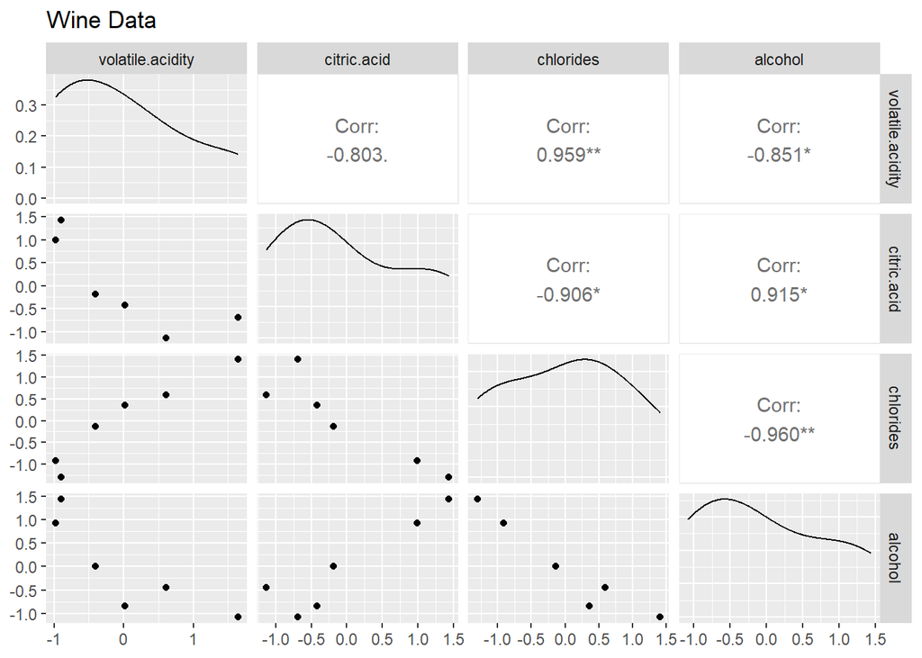

```r
ggpairs(data=matstd.can, title="Wine Data")
```

```r
confint(fit,level=0.95)
```

```
##                       2.5 %    97.5 %
## (Intercept)      -0.1777144 0.1777144
## volatile.acidity  0.1319925 0.8788311
## citric.acid      -0.5839712 0.3873847
## alcohol          -0.9917931 0.1121440
```

4. Prediction (2 points) Average: The predicted value for the “Average” quality category is 0.4208.

Bad: The predicted value for the “Bad” quality category is 1.3731.

Excellent: The predicted value for the “Excellent” quality category is -1.2254.

Good: The predicted value for the “Good” quality category is -0.1840.

Poor: The predicted value for the “Poor” quality category is 0.6163.

Very Good: The predicted value for the “Very Good” quality category is -1.0008

```r
fitted(fit)
```

```
##    Average        Bad  Excellent       Good       Poor  Very Good
##  0.4208355  1.3731047 -1.2254496 -0.1840169  0.6163144 -1.0007881
```

3. Residual Analysis (2 points):

Overall, the residuals provide insight into how well the regression model fits the actual chlorides values.

```r
residuals(fit)
```

```
##     Average         Bad   Excellent        Good        Poor   Very Good
## -0.06106631  0.03065133 -0.07605042  0.04432816 -0.02426639  0.08640362
```

```r
#Anova Table
anova(fit)
```

```
## Analysis of Variance Table
##
## Response: chlorides
##                  Df Sum Sq Mean Sq F value  Pr(>F)
## volatile.acidity  1 4.5960  4.5960 449.007 0.00222 **
## citric.acid       1 0.2632  0.2632  25.718 0.03675 *
## alcohol           1 0.1203  0.1203  11.755 0.07556 .
## Residuals         2 0.0205  0.0102
## ---
## Signif. codes:  0 '***' 0.001 '**' 0.01 '*' 0.05 '.' 0.1 ' ' 1
```

```r
vcov(fit)
```

```
##                    (Intercept) volatile.acidity   citric.acid       alcohol
## (Intercept)       1.705974e-03     6.354417e-18 -1.273263e-17  1.928715e-17
## volatile.acidity  6.354417e-18     7.532185e-03  1.102057e-03  5.403805e-03
## citric.acid      -1.273263e-17     1.102057e-03  1.274161e-02 -1.072071e-02
## alcohol           1.928715e-17     5.403805e-03 -1.072071e-02  1.645721e-02
```

```r
cov2cor(vcov(fit))
```

```
##                    (Intercept) volatile.acidity   citric.acid       alcohol
## (Intercept)       1.000000e+00     1.772674e-15 -2.730988e-15  3.640021e-15
## volatile.acidity  1.772674e-15     1.000000e+00  1.124945e-01  4.853568e-01
## citric.acid      -2.730988e-15     1.124945e-01  1.000000e+00 -7.403438e-01
## alcohol           3.640021e-15     4.853568e-01 -7.403438e-01  1.000000e+00
```

```r
temp <- influence.measures(fit)
temp
```

```
## Influence measures of
##   lm(formula = chlorides ~ volatile.acidity + citric.acid + alcohol,      data = matstd.can) :
##
##           dfb.1_ dfb.vlt. dfb.ctr. dfb.alch  dffit    cov.r cook.d   hat inf
## Average   -1.762    2.401   -1.424  3.10340 -3.798  0.09695 1.3870 0.774   *
## Bad        3.490    5.629    3.446 -0.98857  8.302  0.39632 6.6785 0.943   *
## Excellent -2.150   -1.563   -0.860 -1.40211 -4.359  0.00566 0.9762 0.685   *
## Good       0.209   -0.188   -0.128 -0.00506  0.301 12.96456 0.0388 0.346   *
## Poor      -0.586   -0.163    1.130 -0.90318 -1.336 45.40121 0.7000 0.867   *
## Very Good  0.628   -0.224    0.217 -0.07852  0.955  0.71402 0.1856 0.385
```

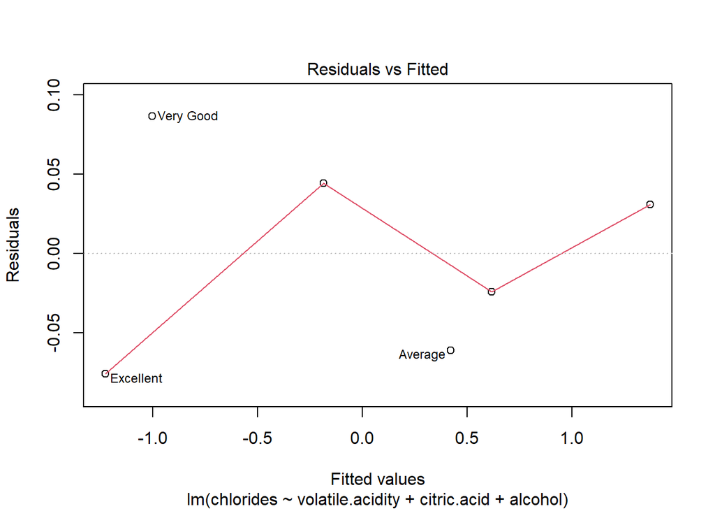

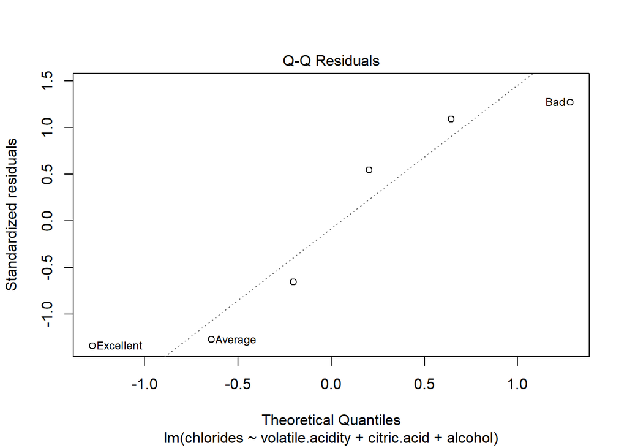

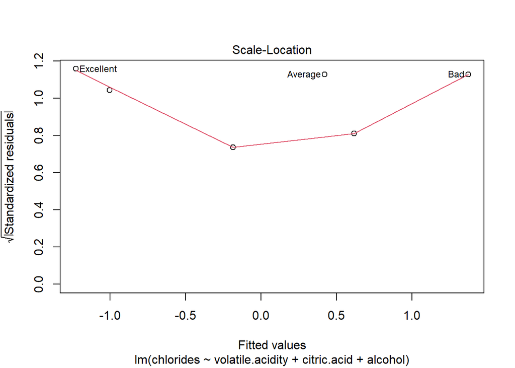

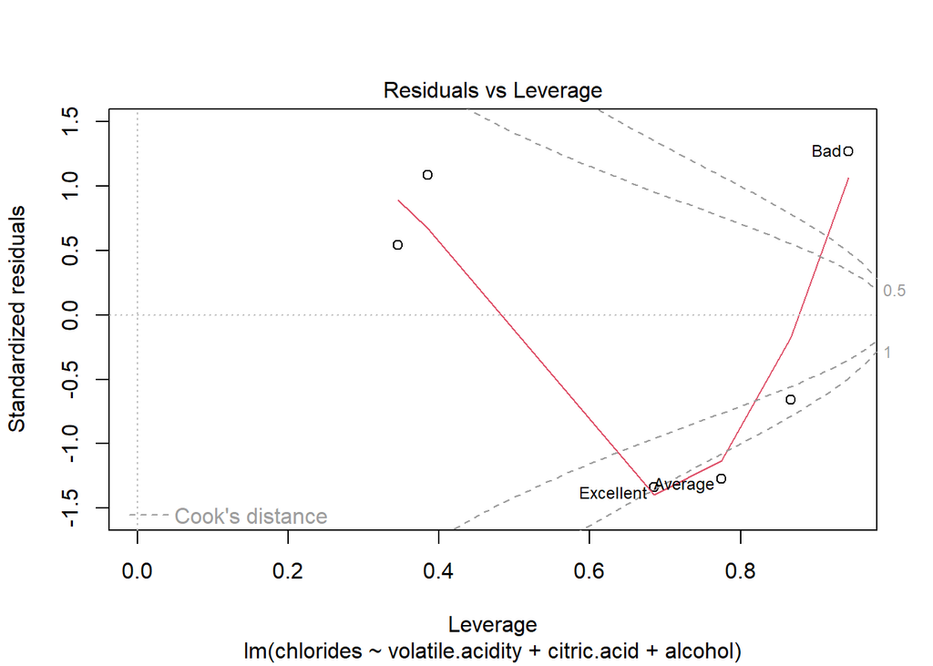

```r
plot(fit)
```

```r
library(car)
outlierTest(fit)
```

```
## No Studentized residuals with Bonferroni p < 0.05
## Largest |rstudent|:
##            rstudent unadjusted p-value Bonferroni p
## Excellent -2.955303            0.20772           NA
```

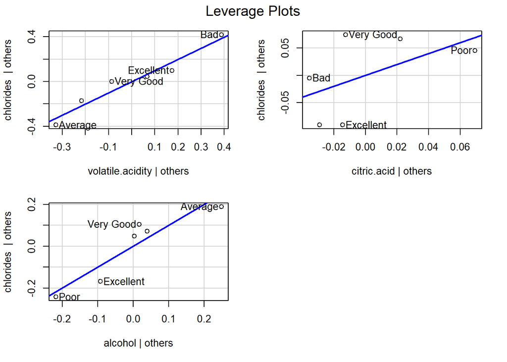

```r
leveragePlots(fit) # leverage plots
```

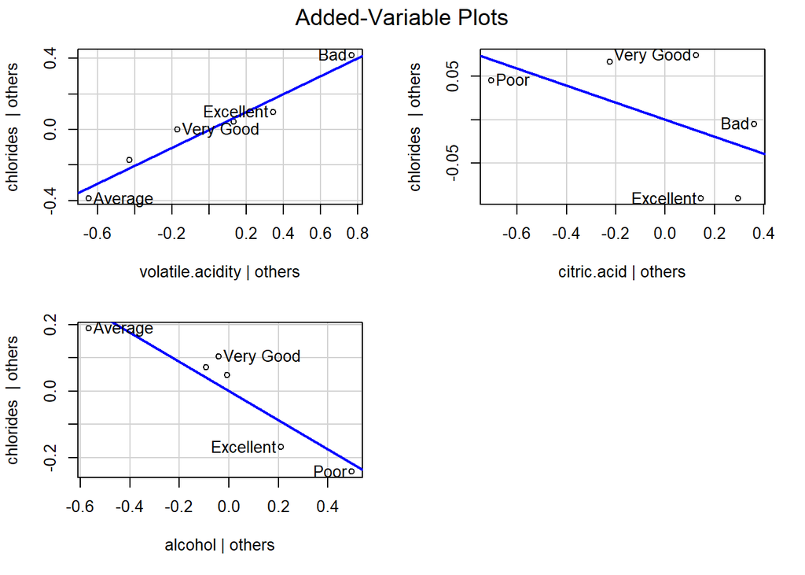

```r
# Influential Observations
# added variable plots
avPlots(fit)
```

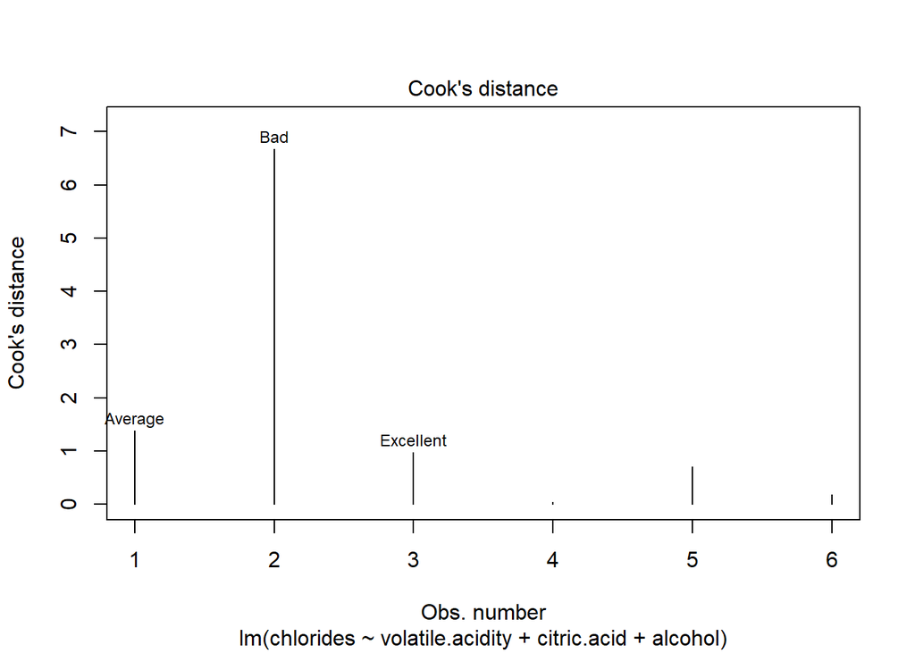

```r
# Cook's D plot
# identify D values > 4/(n-k-1)
cutoff <- 4/((nrow(mtcars)-length(fit$coefficients)-2))
plot(fit, which=4, cook.levels=cutoff)
```

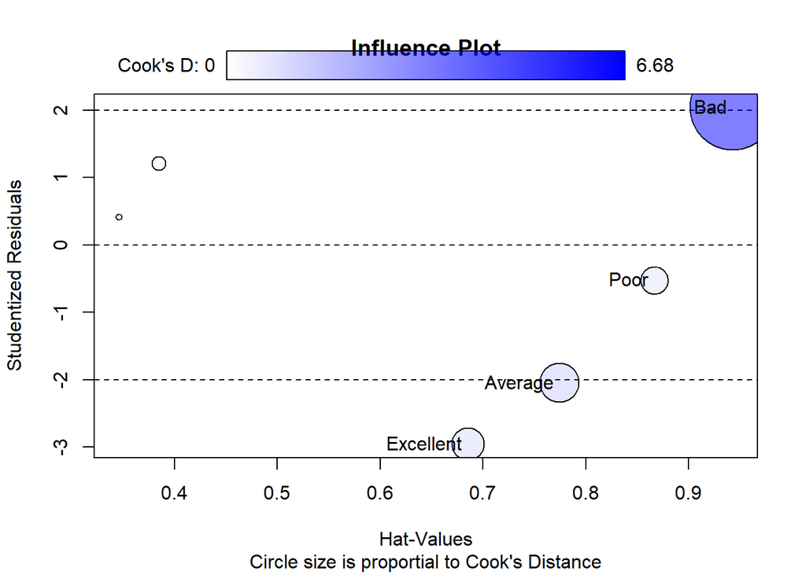

```
##              StudRes       Hat     CookD
## Average   -2.0496697 0.7744822 1.3869774
## Bad        2.0397429 0.9430767 6.6785411
## Excellent -2.9553029 0.6851320 0.9761950
## Poor      -0.5242327 0.8665689 0.7000279
```

```r
# Influence Plot
influencePlot(fit, id.method="identify", main="Influence Plot", sub="Circle size is proportial to Cook's Distance" )
```

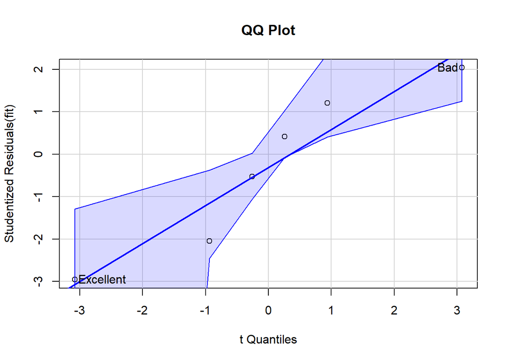

```
##       Bad Excellent
##         2         3
```

```r
# Normality of Residuals
# qq plot for studentized resid
qqPlot(fit, main="QQ Plot")
```

```r
# distribution of studentized residual
```

5. Model Accuracy (2 points)

Variance Formula: The test evaluates the variance of the residuals using a formula that includes the fitted values of the model.

Chisquare and p-value: The chi-square statistic is 1.180393 with 1 degree of freedom, resulting in a p-value of 0.27728.

Since the p-value is greater than the significance level of 0.05, we fail to reject the null hypothesis. This suggests that there is no evidence to conclude that the variance of the residuals significantly differs across different levels of the fitted values.

Suggested Power Transformation: The suggested power transformation value is 0.7426849. This transformation can be applied to the model to potentially address issues related to non-constant variance.

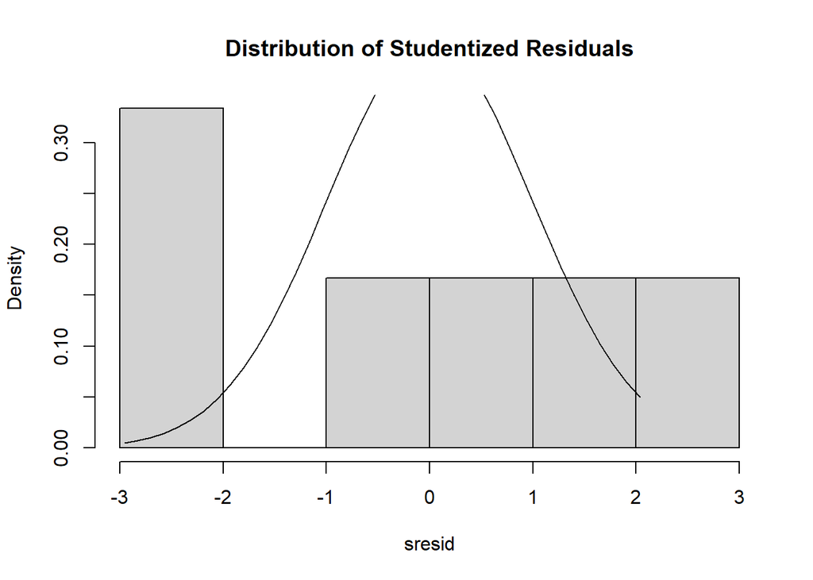

```r
library(MASS)
sresid <- studres(fit)
hist(sresid, freq=FALSE,
     main="Distribution of Studentized Residuals")
xfit<-seq(min(sresid),max(sresid),length=40)
yfit<-dnorm(xfit)
lines(xfit, yfit)
```

```r
#Non-constant Error Variance
# Evaluate homoscedasticity
# non-constant error variance test
ncvTest(fit)
```

```
## Non-constant Variance Score Test
## Variance formula: ~ fitted.values
## Chisquare = 1.180393, Df = 1, p = 0.27728
```

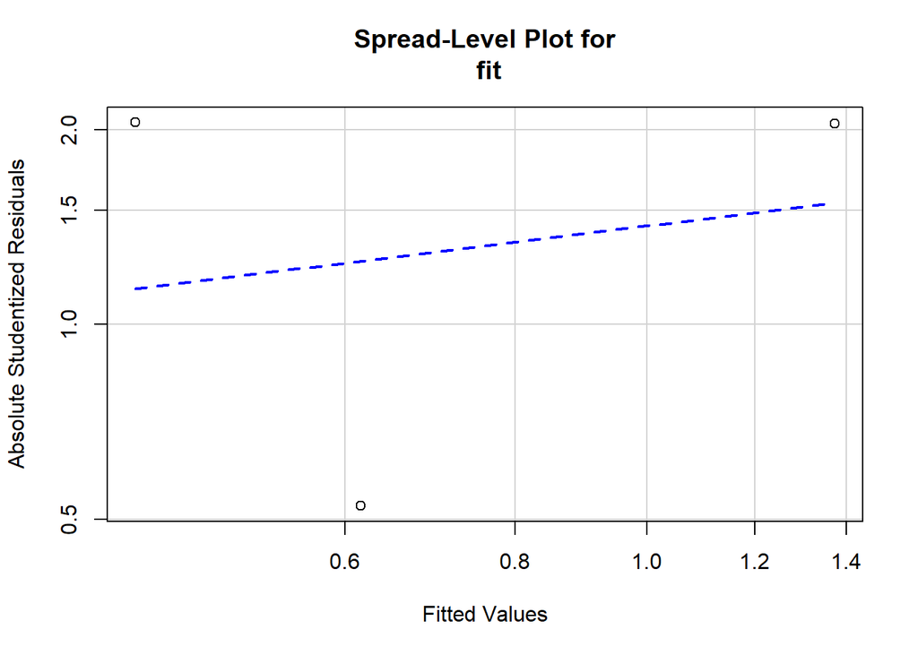

```
##
## Suggested power transformation:  0.7426849
```

```r
# plot studentized residuals vs. fitted values
spreadLevelPlot(fit)
```

volatile.acidity: The VIF value of 3.679 suggests moderate multicollinearity, indicating that the variance of the coefficient estimate for volatile.acidity is inflated by approximately 3.68 times due to its correlation with other predictor variables.

citric.acid: The VIF value of 6.224 indicates a higher degree of multicollinearity, suggesting that the variance of the coefficient estimate for citric.acid is inflated by approximately 6.22 times due to its correlation with other predictor variables.

alcohol: The VIF value of 8.039 indicates a significant multicollinearity issue, implying that the variance of the coefficient estimate for alcohol is inflated by approximately 8.04 times due to its correlation with other predictor variables.

```r
#Multi-collinearity
# Evaluate Collinearity
vif(fit) # variance inflation factors
```

```
## volatile.acidity      citric.acid          alcohol
##         3.679317         6.224012         8.039006
```

```r
sqrt(vif(fit)) > 2 # problem?
```

```
## volatile.acidity      citric.acid          alcohol
##            FALSE             TRUE             TRUE
```

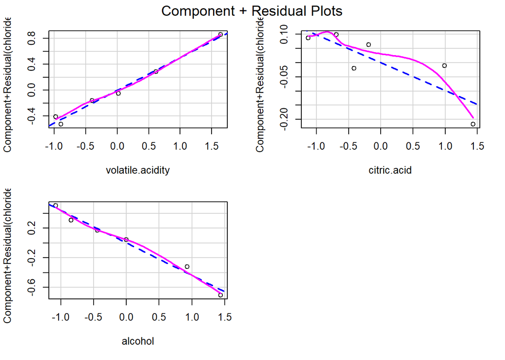

```r
#Nonlinearity
# component + residual plot
crPlots(fit)
```

```r
#Non-independence of Errors
# Test for Autocorrelated Errors
durbinWatsonTest(fit)
```

```
##  lag Autocorrelation D-W Statistic p-value
##    1      -0.5249382      2.503039   0.704
##  Alternative hypothesis: rho != 0
```

```r
# Global test of model assumptions
library(gvlma)
gvmodel <- gvlma(fit)
summary(gvmodel)
```

```
##
## Call:
## lm(formula = chlorides ~ volatile.acidity + citric.acid + alcohol,
##     data = matstd.can)
##
## Residuals:
##   Average       Bad Excellent      Good      Poor Very Good
##  -0.06107   0.03065  -0.07605   0.04433  -0.02427   0.08640
##
## Coefficients:
##                    Estimate Std. Error t value Pr(>|t|)
## (Intercept)      -1.816e-16  4.130e-02   0.000   1.0000
## volatile.acidity  5.054e-01  8.679e-02   5.824   0.0282 *
## citric.acid      -9.829e-02  1.129e-01  -0.871   0.4757
## alcohol          -4.398e-01  1.283e-01  -3.428   0.0756 .
## ---
## Signif. codes:  0 '***' 0.001 '**' 0.01 '*' 0.05 '.' 0.1 ' ' 1
##
## Residual standard error: 0.1012 on 2 degrees of freedom
## Multiple R-squared:  0.9959, Adjusted R-squared:  0.9898
## F-statistic: 162.2 on 3 and 2 DF,  p-value: 0.006135
##
##
## ASSESSMENT OF THE LINEAR MODEL ASSUMPTIONS
## USING THE GLOBAL TEST ON 4 DEGREES-OF-FREEDOM:
## Level of Significance =  0.05
##
## Call:
##  gvlma(x = fit)
##
##                       Value p-value                Decision
## Global Stat        1.785996  0.7750 Assumptions acceptable.
## Skewness           0.004375  0.9473 Assumptions acceptable.
## Kurtosis           0.526481  0.4681 Assumptions acceptable.
## Link Function      1.138090  0.2861 Assumptions acceptable.
## Heteroscedasticity 0.117050  0.7323 Assumptions acceptable.
```

```r
fit
```

```
##
## Call:
## lm(formula = chlorides ~ volatile.acidity + citric.acid + alcohol,
##     data = matstd.can)
##
## Coefficients:
##      (Intercept)  volatile.acidity       citric.acid           alcohol
##       -1.816e-16         5.054e-01        -9.829e-02        -4.398e-01
```

```r
summary(fit)
```

```
##
## Call:
## lm(formula = chlorides ~ volatile.acidity + citric.acid + alcohol,
##     data = matstd.can)
##
## Residuals:
##   Average       Bad Excellent      Good      Poor Very Good
##  -0.06107   0.03065  -0.07605   0.04433  -0.02427   0.08640
##
## Coefficients:
##                    Estimate Std. Error t value Pr(>|t|)
## (Intercept)      -1.816e-16  4.130e-02   0.000   1.0000
## volatile.acidity  5.054e-01  8.679e-02   5.824   0.0282 *
## citric.acid      -9.829e-02  1.129e-01  -0.871   0.4757
## alcohol          -4.398e-01  1.283e-01  -3.428   0.0756 .
## ---
## Signif. codes:  0 '***' 0.001 '**' 0.01 '*' 0.05 '.' 0.1 ' ' 1
##
## Residual standard error: 0.1012 on 2 degrees of freedom
## Multiple R-squared:  0.9959, Adjusted R-squared:  0.9898
## F-statistic: 162.2 on 3 and 2 DF,  p-value: 0.006135
```

```r
fit1 <- fit
fit2 <- lm(mpg ~ disp + hp + wt, data = mtcars)
# compare models
anova(fit1, fit2)
```

[output not shown]

```r
step <- stepAIC(fit, direction="both")
```

```
## Start:  AIC=-26.08
## chlorides ~ volatile.acidity + citric.acid + alcohol
##
##                    Df Sum of Sq     RSS     AIC
## - citric.acid       1   0.00776 0.02823 -26.154
## <none>                          0.02047 -26.083
## - alcohol           1   0.12032 0.14079 -16.514
## - volatile.acidity  1   0.34713 0.36760 -10.755
##
## Step:  AIC=-26.15
## chlorides ~ volatile.acidity + alcohol
##
##                    Df Sum of Sq     RSS     AIC
## <none>                          0.02823 -26.154
## + citric.acid       1   0.00776 0.02047 -26.083
## - volatile.acidity  1   0.36351 0.39174 -12.373
## - alcohol           1   0.37580 0.40403 -12.188
```

```r
step$anova # display results
```

```
## Stepwise Model Path
## Analysis of Deviance Table
##
## Initial Model:
## chlorides ~ volatile.acidity + citric.acid + alcohol
##
## Final Model:
## chlorides ~ volatile.acidity + alcohol
##
##
##            Step Df    Deviance Resid. Df Resid. Dev       AIC
## 1                                      2 0.02047169 -26.08283
## 2 - citric.acid  1 0.007761521         3 0.02823322 -26.15409
```

```r
library(leaps)
```

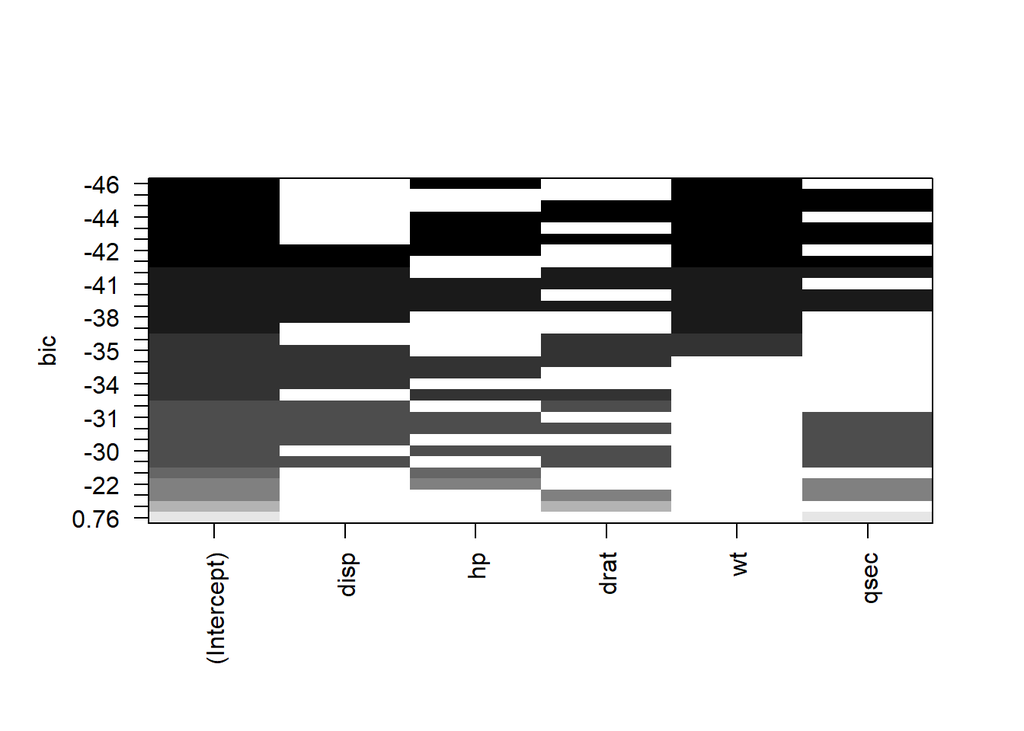

```r
leaps<-regsubsets(mpg~disp+hp+drat+wt+qsec,data=mtcars,nbest=10)
# view results
plot(leaps)
```

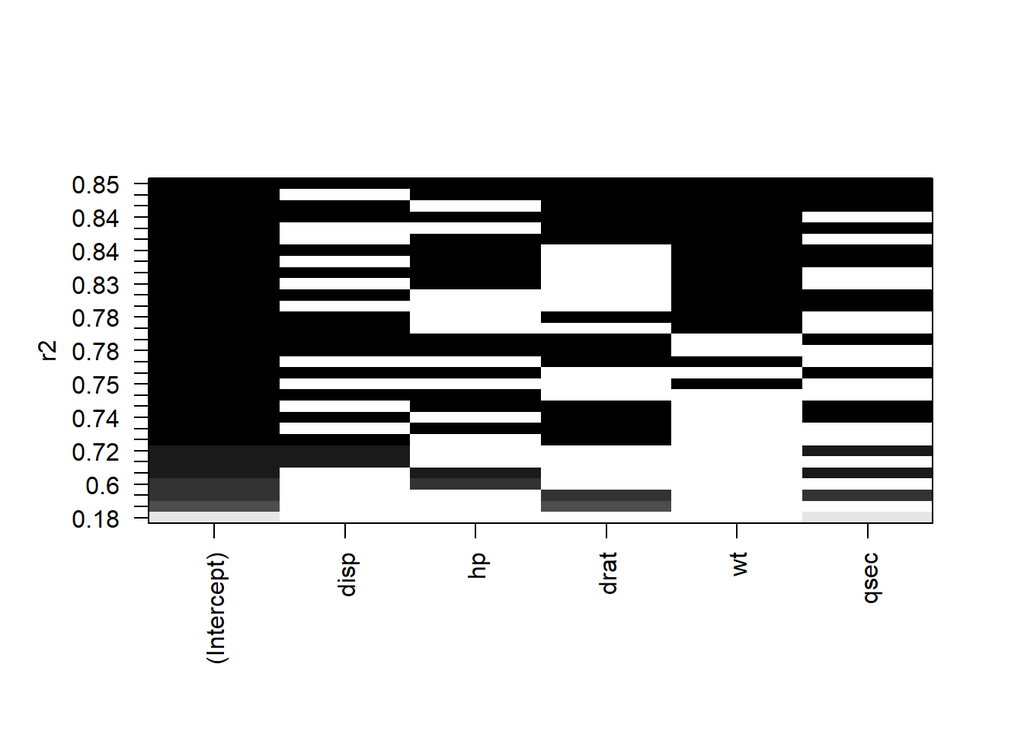

```r
plot(leaps,scale="r2")
```

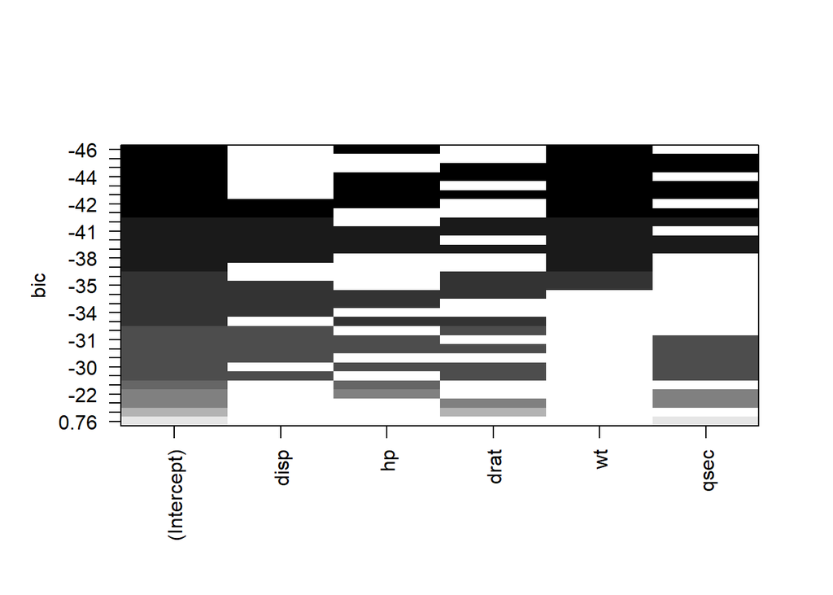

```r
plot(leaps,scale="bic")
```

```r
summary(leaps)
```

```
## Subset selection object
## Call: regsubsets.formula(mpg ~ disp + hp + drat + wt + qsec, data = mtcars,
##     nbest = 10)
## 5 Variables  (and intercept)
##      Forced in Forced out
## disp     FALSE      FALSE
## hp       FALSE      FALSE
## drat     FALSE      FALSE
## wt       FALSE      FALSE
## qsec     FALSE      FALSE
## 10 subsets of each size up to 5
## Selection Algorithm: exhaustive
##           disp hp  drat wt  qsec
## 1  ( 1 )  " "  " " " "  "*" " "
## 1  ( 2 )  "*"  " " " "  " " " "
```

[output cut: 29 more lines]

```r
library(relaimpo)
calc.relimp(fit,type=c("lmg","last","first","pratt"),
            rela=TRUE)
```

```
## Response variable: chlorides
## Total response variance: 1
## Analysis based on 6 observations
##
## 3 Regressors:
## volatile.acidity citric.acid alcohol
## Proportion of variance explained by model: 99.59%
## Metrics are normalized to sum to 100% (rela=TRUE).
##
## Relative importance metrics:
##
##                        lmg       last     first      pratt
## volatile.acidity 0.3681878 0.73048013 0.3452309 0.48655368
## citric.acid      0.2851651 0.01633284 0.3086151 0.08946697
## alcohol          0.3466471 0.25318703 0.3461540 0.42397935
##
## Average coefficients for different model sizes:
##
##                          1X        2Xs         3Xs
## volatile.acidity  0.9587461  0.5818719  0.50541178
## citric.acid      -0.9064781 -0.2785248 -0.09829324
## alcohol          -0.9600270 -0.6624747 -0.43982455
```